# Part I - Used Cars Data

## Introduction

> The dataset is madeup of 7906 rows and 18 columns in general. Based on various market surveys, the consulting firm has gathered a large dataset of different types of used cars across the market. The dataset is madeup of different information about used cars gotten from [kaggle.](https://www.kaggle.com/datasets/shubham1kumar/usedcar-data?resource=download). The description of data can be gotten from [here](https://www.kaggle.com/datasets/shubham1kumar/usedcar-data?resource=download).

> Data Dictionary:
> - Sales_ID (Sales ID)
> - name (Name of the used car)
> - year (Year of the car purchase)
> - selling_price (Current selling price for used car)
> - km_driven (Total km driven)
> - Region (Region where it is used)
> - State or Province (State or Province where it is used)
> - City (City where it is used)
> - fuel (Fuel type)
> - seller_type (Who is selling the car)
> - transmission (Transmission type of the car)
> - transmission (Transmission type of the car)
> - owner (Owner type)
> - mileage (Mileage of the car)
> - engine (engine power)
> - max_power (max power)
> - seats (Number of seats)
> - sold (used car sold or not)

## Preliminary Wrangling

```python
# import all packages and set plots to be embedded inline
import numpy as np
import pandas as pd
import matplotlib.pyplot as plt
import seaborn as sb

%matplotlib inline
```

```python
# load the dataset for the project
df = pd.read_csv('./UserCarData.csv')
```

```python
# viewing the dataframe
df.head()
```

|  | Sales_ID | name | year | selling_price | km_driven | Region | State or Province | City | fuel | seller_type | transmission | owner | mileage | engine | max_power | torque | seats | sold |
| --- | --- | --- | --- | --- | --- | --- | --- | --- | --- | --- | --- | --- | --- | --- | --- | --- | --- | --- |
| 0 | 1 | Maruti | 2014 | 450000 | 145500 | East | District of Columbia | Washington | Diesel | Individual | Manual | First_Owner | 23.40 | 1248 | 74.00 | 190Nm@ 2000rpm | 5 | Y |
| 1 | 2 | Skoda | 2014 | 370000 | 120000 | East | New York | New York City | Diesel | Individual | Manual | Second_Owner | 21.14 | 1498 | 103.52 | 250Nm@ 1500-2500rpm | 5 | Y |
| 2 | 3 | Honda | 2006 | 158000 | 140000 | Central | Illinois | Chicago | Petrol | Individual | Manual | Third_Owner | 17.70 | 1497 | 78.00 | 12.7@ 2,700(kgm@ rpm) | 5 | Y |
| 3 | 4 | Hyundai | 2010 | 225000 | 127000 | Central | Illinois | Chicago | Diesel | Individual | Manual | First_Owner | 23.00 | 1396 | 90.00 | 22.4 kgm at 1750-2750rpm | 5 | Y |
| 4 | 5 | Maruti | 2007 | 130000 | 120000 | East | New York | New York City | Petrol | Individual | Manual | First_Owner | 16.10 | 1298 | 88.20 | 11.5@ 4,500(kgm@ rpm) | 5 | Y |

```python
# Describe data properties
print(df.shape)
df.describe()
```

```
(7906, 18)
```

|  | Sales_ID | year | selling_price | km_driven | mileage | engine | max_power | seats |
| --- | --- | --- | --- | --- | --- | --- | --- | --- |
| count | 7906.000000 | 7906.000000 | 7.906000e+03 | 7.906000e+03 | 7906.000000 | 7906.000000 | 7906.000000 | 7906.000000 |
| mean | 4070.106248 | 2013.983936 | 6.498137e+05 | 6.918866e+04 | 19.419861 | 1458.708829 | 91.587374 | 5.416393 |
| std | 2345.770159 | 3.863695 | 8.135827e+05 | 5.679230e+04 | 4.036263 | 503.893057 | 35.747216 | 0.959208 |
| min | 1.000000 | 1994.000000 | 2.999900e+04 | 1.000000e+00 | 0.000000 | 624.000000 | 32.800000 | 2.000000 |
| 25% | 2037.250000 | 2012.000000 | 2.700000e+05 | 3.500000e+04 | 16.780000 | 1197.000000 | 68.050000 | 5.000000 |
| 50% | 4076.500000 | 2015.000000 | 4.500000e+05 | 6.000000e+04 | 19.300000 | 1248.000000 | 82.000000 | 5.000000 |
| 75% | 6102.000000 | 2017.000000 | 6.900000e+05 | 9.542500e+04 | 22.320000 | 1582.000000 | 102.000000 | 5.000000 |
| max | 8128.000000 | 2020.000000 | 1.000000e+07 | 2.360457e+06 | 42.000000 | 3604.000000 | 400.000000 | 14.000000 |

```python
# Data type of variables in the dataframe
df.dtypes
```

```
Sales_ID               int64
name                  object
year                   int64
selling_price          int64
km_driven              int64
Region                object
State or Province     object
City                  object
fuel                  object
seller_type           object
transmission          object
owner                 object
mileage              float64
engine                 int64
max_power            float64
torque                object
seats                  int64
sold                  object
dtype: object
```

```python
# Checking for variables which are category datatype but labelled string
print(df.Region.unique())
print(df.owner.unique())
print(df.fuel.unique())
print(df.seller_type.unique())
print(df.transmission.unique())
print(df.sold.unique())
```

```
['East' 'Central' 'West' 'South']
['First_Owner' 'Second_Owner' 'Third_Owner' 'Fourth_Above_Owner'
 'Test_Drive_Car']
['Diesel' 'Petrol' 'LPG' 'CNG']
['Individual' 'Dealer' 'Trustmark_Dealer']
['Manual' 'Automatic']
['Y' 'N']
```

```python
# change variables to category data type
cat_var=['Region','fuel','seller_type', 'transmission', 'sold']
for var in cat_var:
    df[var] = df[var].astype('category')
```

```python
# Change owner to ordered category data type seeing that it is a ordinal qualitative variable
owner_level = ['Fourth_Above_Owner', 'Third_Owner', 'Second_Owner', 'First_Owner', 'Test_Drive_Car']
owner_levels = pd.api.types.CategoricalDtype(categories=owner_level, ordered=True)
df.owner = df.owner.astype(owner_levels)
```

```python
# Testing for the effect of the changes
df.dtypes
```

```
Sales_ID                int64
name                   object
year                    int64
selling_price           int64
km_driven               int64
Region               category
State or Province      object
City                   object
fuel                 category
seller_type          category
transmission         category
owner                category
mileage               float64
engine                  int64
max_power             float64
torque                 object
seats                   int64
sold                 category
dtype: object
```

### What is/are the main feature(s) of interest in your dataset?

> My main focus is to see the main features that affect the selling price of the used cars.

### What features in the dataset do you think will help support your investigation into your feature(s) of interest?

> Some of the features that I presume will dictate the prices of cars are mileage, engine, seats, seller_type, fuel type and the transmission type.

```python
# Functions for various plots
def Hist_bin(data, x, xlabel, ylabel, title, bins):
    import matplotlib.pyplot as plt
    plt.hist(data=data, x=x, bins=bins)
    plt.xlabel(xlabel)
    plt.ylabel(ylabel)
    plt.title(title, loc='center');

def Hist(data, x, xlabel, ylabel, title):
    import matplotlib.pyplot as plt
    plt.hist(data=data, x=x)
    plt.xlabel(xlabel)
    plt.ylabel(ylabel)
    plt.title(title, loc='center');

def Scatter(data, x, y, xlabel, ylabel):
    import matplotlib.pyplot as plt
    plt.scatter(data=data, x=x, y=y, alpha=0.2)
    plt.xlabel(xlabel)
    plt.ylabel(ylabel);

def violin(data, x, y, title):
    import seaborn as sb
    a = sb.violinplot(data=data, x=x, y=y, inner=None, color=def_color);
    plt.title(title);

def Box(data, x, y, title):
    import seaborn as sb
    a = sb.boxplot(data=data, x=x, y=y, color=def_color);
    plt.title(title);

def Facet(data, col, colwrap, map_func, var1, var2):
    a = sb.FacetGrid(data=data, col=col, col_wrap=colwrap, height=4)
    a.map(map_func, var1, var2)
    a.set_titles('{col_name}');
```

## Univariate Exploration

> I will like to start by viewing the distribution of price across the dataset.

##### Question

What is the distribution of the selling price in the dataset?

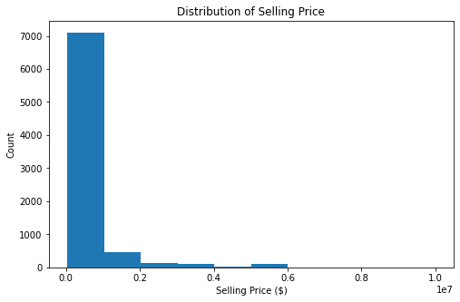

```python
# Distribution of selling price of used cars
plt.figure(figsize=(8,5))
Hist(df, 'selling_price', 'Selling Price ($)', 'Count', 'Distribution of Selling Price')
```

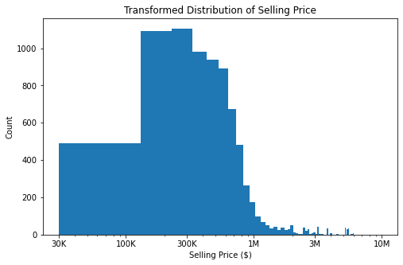

```python
# Transformed distribution of selling price of used cars
bin=np.arange(30000, 10000000, 100000)
plt.figure(figsize=(8,5))
Hist_bin(df, 'selling_price', 'Selling Price ($)', 'Count', 'Transformed Distribution of Selling Price', bins=bin)
plt.xscale('log')
plt.xticks([30000,100000,300000,1000000,3000000,10000000], ['30K','100K','300K','1M','3M','10M']);
```

##### Observation

In a bit to look at the distribution of selling price across the data set, the histogram shows that cars whose selling price is between \$30,000 and \\$1,000,000 are much in the dataset. But in order to dive deeper into the dataset, log transformation was carried out on the price axis, this later shows that the price distribution is a unimodal distribution in which the modal price is in between \$300,000 and \\$400,000. After \$1,000,000, it was oberved that the price is rising and falling in the counts.

##### Question

What is the distribution of the number of seats of cars in the dataset?

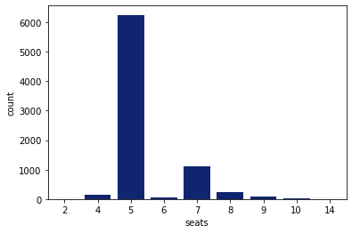

```python
# Distribution of seats across the dataset
def_color = sb.color_palette('dark')[0]
sb.countplot(data=df, x='seats', color=def_color);
```

##### Observation

The above chart shows that cars with 5 seats are more common in the dataset follows by the one with 7 seats. Cars with other number of seats are relevantly small in the dataset compared to this two. Because of the low number of cars in the dataset where the number of seats are 2 and 14, they appear as if there are no representation for them in the dataset. Hence, I transform the count axis to accomodate the one with low count.

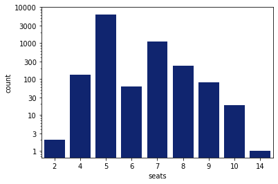

```python
# further distribution of seats in the dataset
ax = sb.countplot(data=df, x='seats', color=def_color);
ax.set_yscale('log')
ax.set_yticks([1,3,10,30,100,300,1000,3000,10000], [1,3,10,30,100,300,1000,3000,10000]);
```

##### Question

What is the distribution of the fuel types in the dataset?

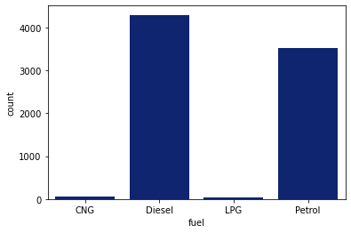

```python
# Distribution of fuel_type in the dataset
sb.countplot(data=df, x='fuel', color=def_color);
```

##### Observation

The plot above shows that diesel and petrol has the largest share of fuel type for cars in the data set.

##### Question

What is the distribution of the km driven in the dataset?

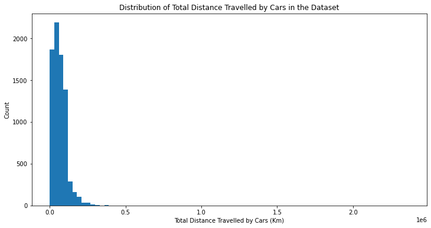

```python
# Distribution of km driven by cars in the dataset
plt.figure(figsize=(12,6));
km_bin = np.arange(df.km_driven.min(), df.km_driven.max()+30000, 30000)
Hist_bin(df, 'km_driven',bins=km_bin, xlabel='Total Distance Travelled by Cars (Km)', ylabel='Count', title='Distribution of Total Distance Travelled by Cars in the Dataset')
```

##### Question

What is the distribution of the seller-type in the dataset?

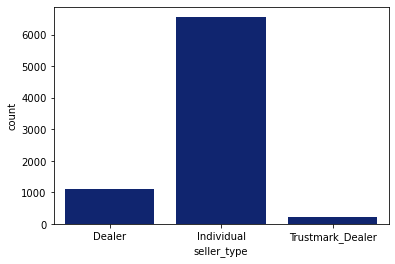

```python
# Distribution of seller types in the dataset
sb.countplot(data=df, x='seller_type', color=def_color);
```

##### Observation

The seller_type distribution of the used cars shows that there are more cars with 'Individual' seller type than 'Dealer' or 'Trustmark_Dealer'. This could be that much dealers are not using this channel or that cars are easily sold by individuals overtime, hence, discouraging more dealers to use the channel.

##### Question

Are more cars sold through this channel?

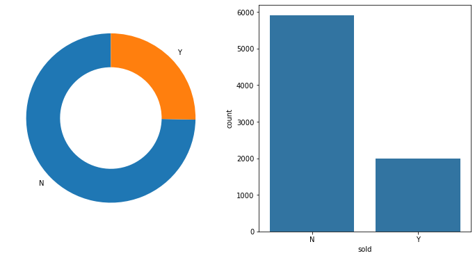

```python
# Distribution of sold and unsold cars in the dataset
sold_distr = df.sold.value_counts()
plt.figure(figsize=(12,6))
plt.subplot(1,2,1)
plt.pie(data=sold_distr, x=sold_distr.values, labels=sold_distr.index, counterclock=True, startangle=90, wedgeprops={'width':0.4});
plt.subplot(1,2,2)
sb.countplot(data=df, x='sold', color=sb.color_palette()[0]);
```

##### Observation

The chart above shows that small number of cars were sold, we will later have to look deeper. Some of the likely questions to raise from this are:

- Is there any variable(s) affecting the sale of cars?
- What kind of car are sold the most? Among many others.

### Discuss the distribution(s) of your variable(s) of interest. Were there any unusual points? Did you need to perform any transformations?

> The distribution of selling price shows that cars whose selling price are relatively low are more in the datasets. The transformation of the price axis gives us a deeper insight into the distribution, where we later saw that it is a unimodal distribution and after a long steeping in the distribution of price, there is a fall and rise in the distribution of price slightly after \$2M.

> For seats, the countplot do not depict the distribution correctly because of the count scale, so, I performed log transformation on the count axis to depict the seats distribution more correctly.

### Of the features you investigated, were there any unusual distributions? Did you perform any operations on the data to tidy, adjust, or change the form of the data? If so, why did you do this?

> Not really, I just extract out some information to construct the pie chart.

## Bivariate Exploration

##### Which variable(s) affect the selling price of cars in the dataset

In a bit to see the factors affecting the selling price of cars in the dataset, I will compare the selling price with some variables in the dataset.

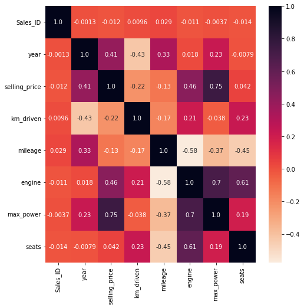

```python
# A heatmap showing correlation between quantitative variables in the dataset
plt.figure(figsize=(8,8))
sb.heatmap(df.corr(), annot=True, cmap='rocket_r', fmt='0.2');
```

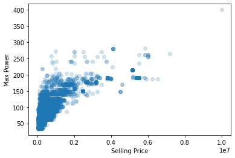

```python
# scatterplot to show the relationship between selling price and max_power of cars
Scatter(df, 'selling_price', 'max_power', xlabel='Selling Price', ylabel='Max Power')
```

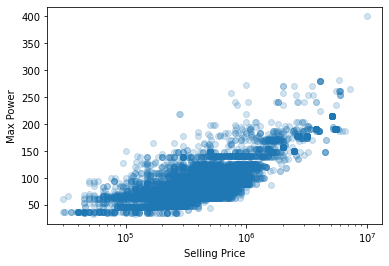

```python
# transformed scatterplot to show the relationship between selling price and max_power of cars
Scatter(df, 'selling_price', 'max_power', xlabel='Selling Price', ylabel='Max Power')
plt.xscale('log');
```

##### Observation

This shows that there is a strong relationship between the selling price of a car and the max_power of the car i.e. as the max_power of cars increases, the selling price also increase and vice versa.

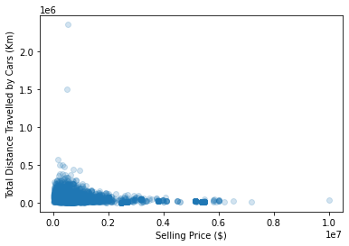

```python
# scatterplot to show the relationship between selling price and km_driven by cars
Scatter(df, 'selling_price', 'km_driven', xlabel='Selling Price ($)', ylabel='Total Distance Travelled by Cars (Km)')
```

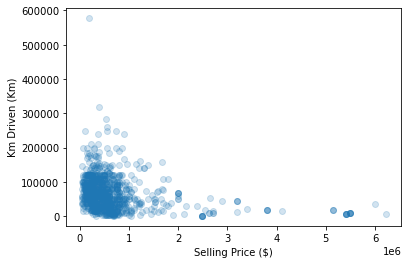

```python
# working with sample data of the dataset to view the effect of km driven on the price of cars
df_sample = df.sample(1000)
Scatter(df_sample, 'selling_price', 'km_driven', xlabel='Selling Price ($)', ylabel='Km Driven (Km)')
```

##### Observation

It was observed that there is a negative correlation between the selling price and km_driven. This implies that an increase in km_driven will lead to a decrease in the selling price.

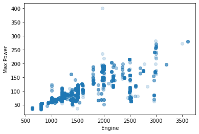

```python
# relationship between engine and max_power
Scatter(df, 'engine', 'max_power', xlabel='Engine', ylabel='Max Power')
```

##### Observation

The scatterplot shows that there is a strong correlation between engine and max_power in the dataset, it simply shows that cars with high engine size has a high max_power. This implies that engine size is a contributing factor that also determine the price of used cars in the dataset.

##### Question

What is the trends of price accross the year?

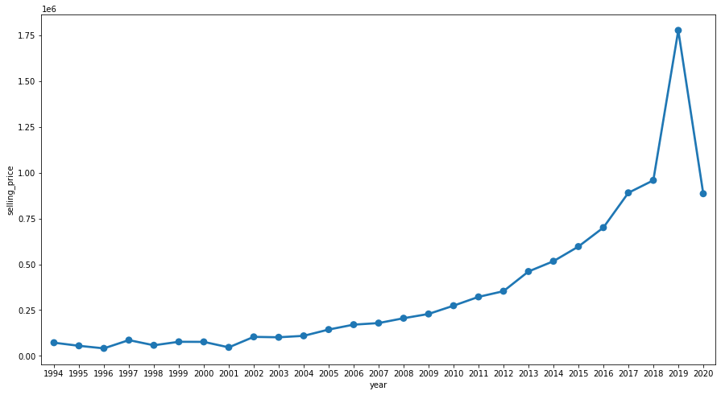

```python
# The trends in price of cars over the year
plt.figure(figsize=(15,8));
sb.pointplot(data=df, x='year', y='selling_price', linestyles='-', ci=0, dodge=True);
```

```python
# Extracting dataset of sold cars from the whole dataset
sold_cars = df.query('sold=="Y"')
```

##### Question

Which region has the highest sales?

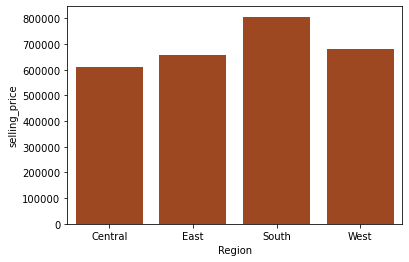

```python
# checking the mean price of sold cars across region
regional_meanprice = sold_cars.groupby('Region').mean()
sb.barplot(data=regional_meanprice, y='selling_price', x=regional_meanprice.index, color=sb.color_palette('dark')[1]);
```

##### Observation

The chart shows that the Southern region has the highest sale in terms of price followed by the West, then East and Central. We can also view the distribution in terms of the number of car sold.

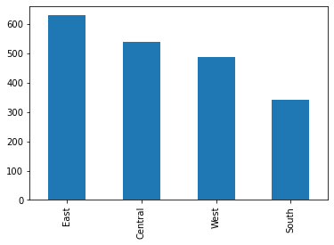

```python
# Regional distribution of sales in terms of the number of cars
regional_sales = sold_cars.Region.value_counts()
regional_sales.plot(kind='bar');
```

##### Observation

The chart shows the distribution of sales across regions, which shows that the East has the highest number of cars sold.

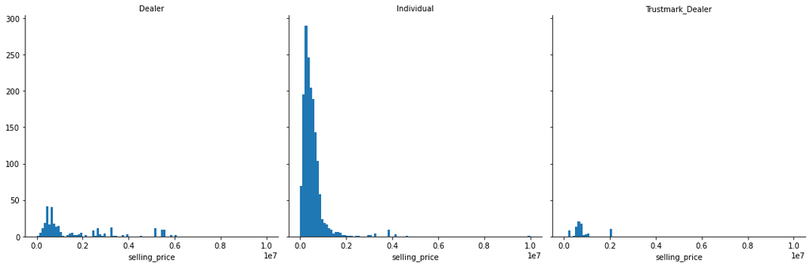

```python
# Distribution of cars based on selling_price across  seller types
x = sb.FacetGrid(data=sold_cars, col='seller_type', height=5,  col_wrap=3)
x.map(plt.hist, 'selling_price', bins=np.arange(0, df.selling_price.max()+100000, 100000))
x.set_titles('{col_name}');
```

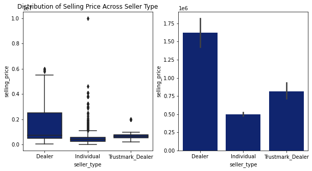

```python
# Distribution of the selling price of sold cars across seller type
plt.figure(figsize=(10,5))
plt.subplot(1,2,1)
Box(sold_cars, 'seller_type', 'selling_price', title='Distribution of Selling Price Across Seller Type')
plt.subplot(1,2,2)
sb.barplot(data=sold_cars, x='seller_type', y='selling_price', color=def_color);
```

##### Observation

This shows that 'Dealer' category has the highest sales in terms of price. The chart also shows that there is a lot of outliers in the 'Individual' category.

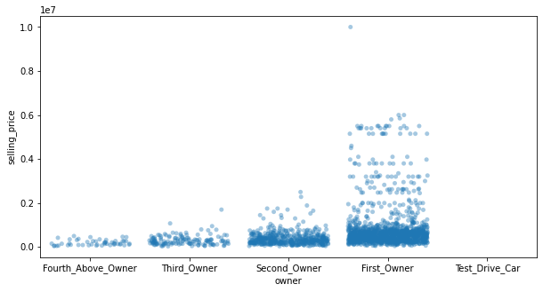

```python
# distribution of cars across owners
plt.figure(figsize=(10,5))
sb.stripplot(data=sold_cars, x='owner', y='selling_price', alpha=0.4, jitter=0.4, color=sb.color_palette()[0]);
```

##### Observation

This shows that the exchange of hands of a car has a great influence on the sale of cars i.e. cars with lower exchange of hands has a greater tendency of sales compared to others with higher change of hands. The chart shows that no test drive cars are sold.

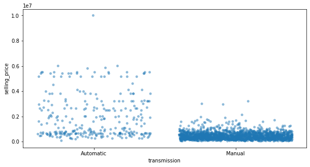

```python
# distribution of cars across transmission
plt.figure(figsize=(10,5))
sb.stripplot(data=sold_cars, x='transmission', y='selling_price', alpha=0.5, jitter=0.4, color=sb.color_palette()[0]);
```

##### Observation

This shows that Automatic transmission has the highest selling price.

##### Question

Did fuel type has anything to do with the mileage of cars in the dataset?

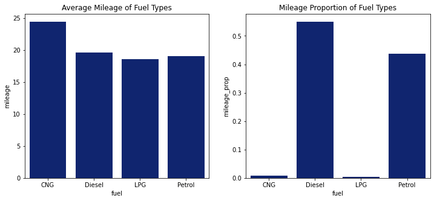

```python
# Relationship between fuel types and mileage of cars
sum = df.groupby('fuel').sum()
total_mileage=df.mileage.sum()
sum['mileage_prop'] = sum.mileage/total_mileage
plt.figure(figsize=(12,5))
plt.subplot(1,2,1)
ax = sb.barplot(data=df, x='fuel', y='mileage', ci=0, color=def_color)
ax.set_title('Average Mileage of Fuel Types');
plt.subplot(1,2,2)
ax = sb.barplot(data=sum, x=sum.index, y='mileage_prop', ci=0, color=def_color)
ax.set_title('Mileage Proportion of Fuel Types');
```

##### Observation

The average mileage (mpg) of cars with various fuel types shows that cars using CNG are good for fuel economy followed by the one using diesel. Mileage proportion of fuel types shows that cars using diesel has the largest proportion of the total mileage in the dataset, recall that diesel has the largest distribution of fuel types in the dataset, hence, taking the largest proportion of mileage.

### Talk about some of the relationships you observed in this part of the investigation. How did the feature(s) of interest vary with other features in the dataset?

> The exploration above shows that max_power is one of the contributing factors that determines the price of used cars.Also, it was also observed that there is a negative correlation between the selling price and km_driven. This implies that an increase in km_driven will lead to a decrease in the selling price.

> The regional distribution of sold cars shows that the Southern region has the highest sale in terms of price followed by the West, then East and Central. We can also view the distribution in terms of the number of car sold.

### Did you observe any interesting relationships between the other features (not the main feature(s) of interest)?

> I observed that there is a strong correlation between engine and max_power in the dataset, it simply shows that cars with high engine size has a high max_power.

## Multivariate Exploration

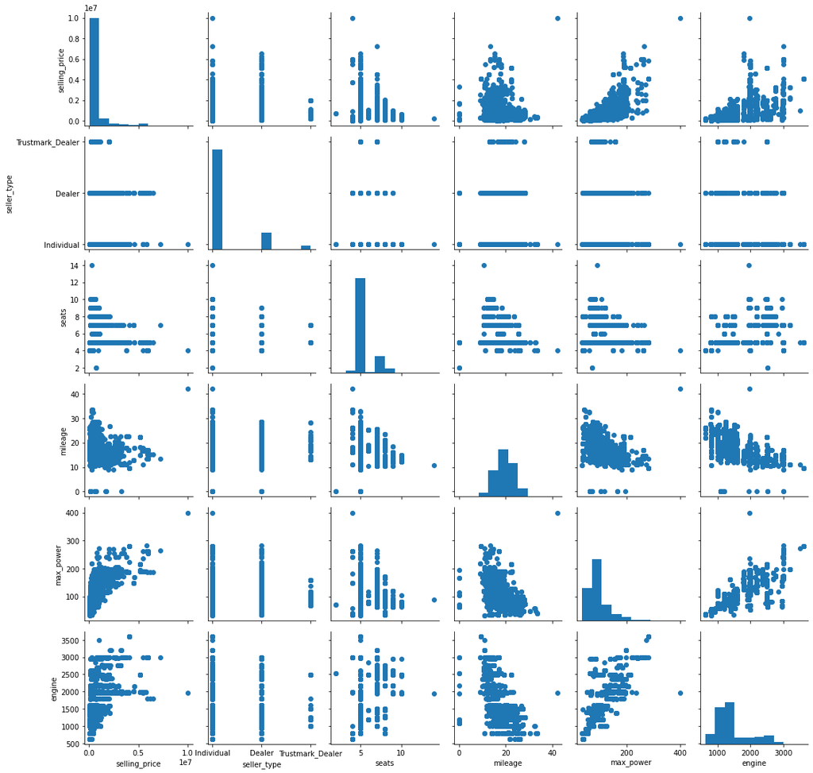

```python
# Viewing the relationship between variables using pairgrid() in seaborn
fx = sb.PairGrid(data=df, vars=['selling_price', 'seller_type', 'seats', 'mileage', 'max_power', 'engine'])
fx.map_offdiag(plt.scatter)
fx.map_diag(plt.hist);
```

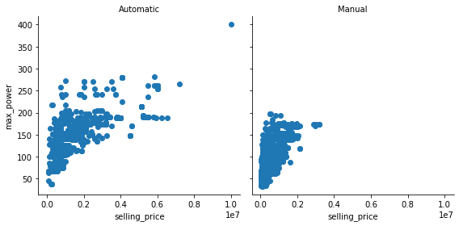

```python
# Relationship between selling price and max_power across transmission types
Facet(df, 'transmission', 2, plt.scatter, 'selling_price', 'max_power')
```

##### Observation

Viewing the correlation between max_power and selling_price across transmission types further shows that an increase in max_power will lead to increase in the selling price of cars as shown in both automatic and manual transmission types.

##### Question

Which of the seller type has high popularity across the regions?

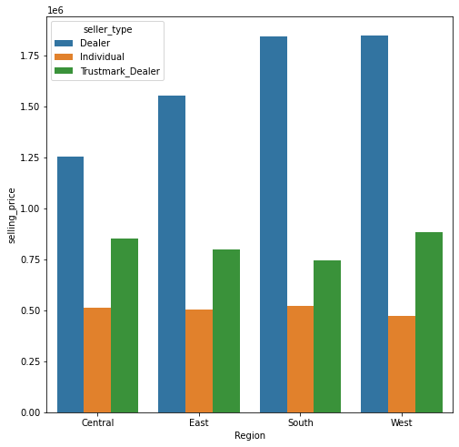

```python
# Relationship between seller type and the selling price across regions
plt.figure(figsize=(8,8))
sb.barplot(data=sold_cars, hue='seller_type', y='selling_price', x='Region', ci=0);
```

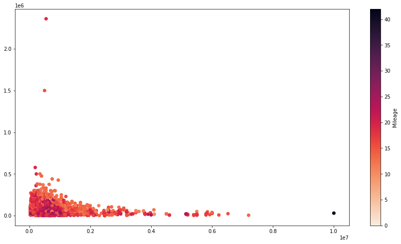

```python
# working with sample data of the dataset to view the effect of km driven on the price of cars
plt.figure(figsize=(15,8))
plt.scatter(data=df, x='selling_price', y='km_driven', c='mileage', cmap='rocket_r')
plt.colorbar(label='Mileage');
```

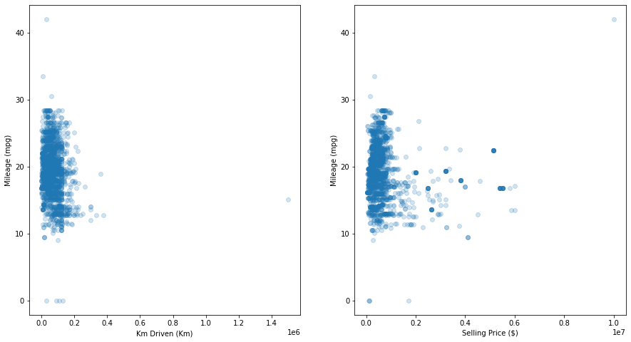

```python
# This further shows mileage does not affect both km driven and selling price
plt.figure(figsize=(15,8))
plt.subplot(1,2,1)
Scatter(sold_cars, 'km_driven', 'mileage', 'Km Driven (Km)', 'Mileage (mpg)')
plt.subplot(1,2,2)
Scatter(sold_cars, 'selling_price', 'mileage', 'Selling Price ($)', 'Mileage (mpg)')
```

##### Observation

The interpolation of mileage levels further shows that mileage doesn't really affect the selling price of cars, neither did it influence km driven of cars. But km driven is inversely proportional to the selling price of cars in the dataset has earlier discussed.

##### Question

Does the trend in prices change from region to region.

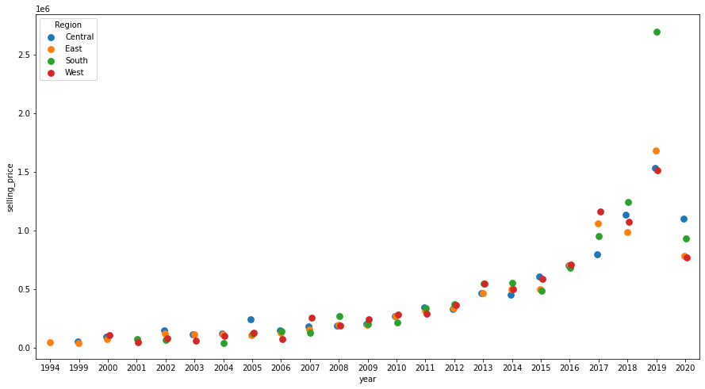

```python
# The trends in price of sold cars over the year across regions
plt.figure(figsize=(15,8));
sb.pointplot(data=sold_cars, x='year', y='selling_price', hue='Region', linestyles='', ci=0, dodge=True);
```

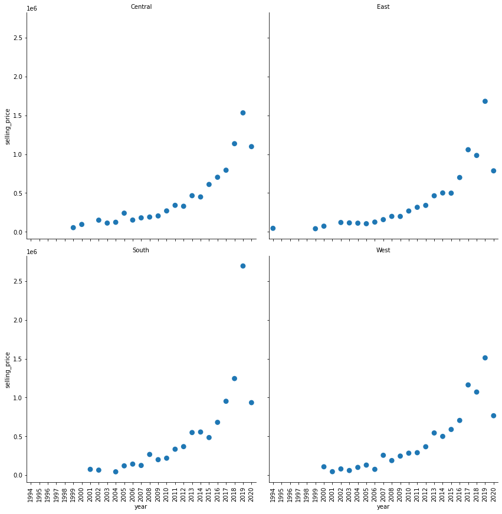

```python
# Faceting the trends in price of cars over the year over regions
f = sb.FacetGrid(data=sold_cars, col='Region', col_wrap=2, height=6)
f.map(sb.pointplot, 'year', 'selling_price', order=np.arange(1994,2021,1), linestyles='', ci=0, dodge=True)
f.set_titles('{col_name}')
f.set_xticklabels(rotation=-270);
```

##### Observation

The charts above shows the trends of price of sold cars over years across regions. The faceting of the region help us to see that some regions do not have sales in some years; like the Southern region which has no sales until 2001 and has no sale in 2003. The faceting also show further that the sales is peak in the year 2019 across the regions as we have it in the general sales. It also shows that the South has the highest sale in 2019 which happens to be outrageous compared to that of other regions.

### Talk about some of the relationships you observed in this part of the investigation. Were there features that strengthened each other in terms of looking at your feature(s) of interest?

> Viewing the correlation between max_power and selling_price across transmission types further shows that an increase in max_power will lead to increase in the selling price of cars as shown in both automatic and manual transmission types. The interpolation of mileage levels when plotting km driven against selling price versus mileage further shows that mileage doesn't really affect the selling price of cars, neither did it influence km driven of cars. But km driven is inversely proportional to the selling price of cars in the dataset has earlier discussed.

## Conclusions

> In a bit to explore the data, I carried out univariate visualization which allow me to see into the distribution of various variables in the dataset across its levels. I also carried out bivariate visualization which shows the relationship between variables while multivariate visualization is used to show the effect of some variables on the relationships in bivariate visualization. The exploration has help to see the strong correlation between max_power and engine variables.